# Group theory general

Manu

28 February 2017

# Group definition

Let G be a finite set with an application $\cdot: G\times G \rightarrow G$. $(G, \cdot)$ is a group iff:

- **Identity** There exists an element we call e such that $\forall g \in G, e \cdot g = g \cdot e = g$
- **Transitivity** $\forall g, h, k \in G, (g \cdot h) \cdot k = g \cdot (h \cdot k)$
- **Inverse** $\forall g \in G, \exists h \in G / gh = hg = e$

We easily show that if there is an identity it must be unique, and that the inverse of an element is also unique.

## Opposite group

If $(G, \cdot)$ is a group then we can construct the opposite group $(G, \cdot_{op})$ the following way:

$$g \cdot_{op} k \mapsto k \cdot g$$

And the isomorphism $G \rightarrow G^{op}$ is given by the identity?

$id(g \cdot k) = g \cdot k$ and $id(g \cdot k) = id(g) \cdot_{op} id(k) = k \cdot g$

Nope it is not.

The isomorphism is given by the map $g \mapsto g^{-1}$ :

$(g \cdot k)^-1 = k^{-1} \cdot g^{-1}$ and $(g \cdot k)^-1 = g^{-1} \cdot_{op} k^{-1} = k^{-1} \cdot g^{-1}$

## Conjugation

For any g in G we can define: $h^g \mapsto ghg^{-1}$ and $h^{*g} \mapsto g^{-1}hg$

Let’s show that both are automorphisms:

$$h^gk^g = ghg^{-1}gkg^{-1} = ghkg^{-1} = (hk)^g$$
So the conjugation is an automorphism.

$$h^{*g}k^{*g} = g^{-1}hgg^{-1}kg = g^{-1}hkg = (hk)^{*g}$$
So the opposite conjugation is also an automorphism.

### As a homomorphism G into Aug(G)

We also get 2 mappings

$$\begin{array}{ll}
conj: G \rightarrow Aut(G) \\
g \mapsto (x \mapsto x^g)
\end{array}$$

and

$$\begin{array}{ll}
conj_{op}: G \rightarrow Aut^{op}(G) \\
g \mapsto (x \mapsto x^{*g})
\end{array}$$

We can check that they are both homomorphisms:

$$conj(g_1) \circ conj(g_2)(x) = conj(g_1)(g_2x{g_2}^{-1}) = g_1g_2x{g_2}^{-1}{g_1}^{-1} = g_1g_2x(g_1g_2)^{-1} = conj(g_1g_2)(x)$$

And similarly for $conj_{op}$:

$$conj_{op}(g_1) \circ conj_{op}(g_2)(x) = conj_{op}(g_2)(conj_{op}(g_1)(x)) = conj(g_2)({g_1}^{-1}xg_1) = {g_2}^{-1}{g_1}^{-1}xg_1g_2 = {g_1g_2}^{-1}xg_1g_2 = conj_{op}(g_1g_2)(x)$$

### What is not homomorphism

This is the proof that $conj_{op}$ is not a homomorphism into Aut(G)
$$conj_{op}(g_1) \circ conj_{op}(g_2)(x) = conj(g_1)({g_2}^{-1}xg_2) = {g_1}^{-1}{g_2}^{-1}xg_2g_1 = {g_2g_1}^{-1}xg_2g_1 = conj(g_2g_1)(x)$$

Similarly we show that $conj$ is not a homomorphism into $Aut_{op}(G)$

# Symmetric group

Let A be any finite set. We define Aut(A) to be the group of all bijection $A \rightarrow A$

And we can define $\forall f, g \in \mathrm{Aut(A)}, \forall a \in A, f \circ g (a) = f(g(a))$ and $f \circ_{op} g(a) = g(f(a))$. These 2 groups are opposite of each other,

# Group action

Similarly we have 2 ways to define a group action of a group G into a set S.

We can define the group action as a morphism $G \rightarrow \mathrm{Aut(S)}$ or as a morphism $G \rightarrow \mathrm{Aut^{op}(S)}$

Let $\phi: G \rightarrow \mathrm{Aut^{op}(S)}$

Then we can define $\forall g \in G, x \in \mathcal{S}, g \bullet_{op}^2 x = \phi(g)(x)$ And we have $\phi(g_1 \cdot g_2)(x) = (\phi(g_1) \circ_{op}\phi(g_2)) (x) = \phi(g2)(\phi(g1)(x)) = \phi(g_2)(g_1 \bullet_{op}^2 x) = g_2 \bullet_{op}^2 g_1 \bullet_{op}^2 x$

But that doesn’t work very well. We can try the following though:

$\forall g \in G, x \in \mathcal{S}, x \bullet_{op} g = \phi(g)(x)$

And we have $x \bullet_{op} g_1g_2= \phi(g_1 \cdot g_2)(x) = (\phi(g_1) \circ_{op}\phi(g_2)) (x) = \phi(g_2)(\phi(g_1)(x)) = \phi(g2)(x \bullet_{op} g_1) = x \bullet_{op} g_1 \bullet_{op} g_2$

# Semidirect product

Let G be a group, N a normal subgroup, K another subgroup such that $G = K \rtimes N$

## 2 ways to write the semidirect product

Let $n \in N, k \in k, g \in G$ Should we write g as nk or as kn?

if we write **g = nk** then: $g_1 \cdot g_2 = n_1k_1 \cdot n_2k_2 = n_1k_1n_2k_1^{-1}k_1k_2 = n_1(k_1n_2k_1^{-1}) \cdot k_1k_2$

$$(k_1, n_1) \cdot (k_2, n_2) = (k_1k_2, n_1k_1n_2k_1^{-1}) = (k_1k_2, n_1n_2^{k_1})$$

if we write **g = kn** then: $g_1 \cdot g_2 = k_1n_1 \cdot k_2n_2 = k_1k_2(k_2^{-1}n_1k_2) \cdot n_2$

$$(k_1, n_1) \cdot (k_2, n_2) = (k_1k_2, ({k_2}^{-1}n_1k_2)n_2) = (k_1k_2, {n_1}^{*k2}n_2)$$

Lot of possibilities:

- 2 ways to define the conjugation
- 2 ways to define the composition of functions
- 2 ways to define the semi-direct product
- 2 ways to define a group action

Are all those definition compatible?

We will show that once we choose an order for the composition of functions there is only one way to define composition and the semi-direct product such that

1. The map $g \mapsto conj(g)$ is a homomorphism
2. The semi-direct product read that way (g1g2, n1 conj(g1)(n2))

## Definition

Since the package *permutations* that I use uses the definition of composition corresponding to the group $Aut_{op}$ then:

- We define the conjugation as $conj_{op}(g)(x) = g^{-1}xg$ because that way the conjugation is a group homomorphism into $Aut_{op}(G)$
- We define the semidirect product as kn (normal term comes second) so that the map from k to Aut(N) is a group homomorphism.

## Properties

Let A, B and C be groups. $f: A \rightarrow C$, $g: B \rightarrow C$ then we have $f \times g : A \times B \rightarrow C$

Note that this isnt true of the semi-direct product: $id_{C(3)}: C(3) \rightarrow C(3)$, and $0: C(2) \rightarrow C(3)$ but there is no map $S3 \rightarrow C(3)$.

**proof** Let l be such a map. C(3) is of order 3 so l(s) = 0. We also have l(r) = r. Then l(srs) = l(s) + l(r) + l(s) = l(r) = 1 But we have also l(srs) = l(r^2) = 2l(r) = 2 Absurd! So l cannot be defined.

# Classes by a subgroup

Let H be a subgroup of G. We write $xH = \{xh | h\in H\}$ and $Hx = \{hx | h\in H\}$

**Lemma** $x \in G, y \in xH$ then $xH = yH$

**Proof**

> $y \in xH \implies y = xh_y \implies yH = xh_yH = xH$

And similarly for the right classes.

**Property** $\{xH | x \in G\}$ is a partition of G.

**Proof**

> if xH and yH have non-null intersection then there is z in both xH and yH and according to the lemma xH = zH = yH and xH = yH. Furthermore the classes clearly cover the whole of G since $\forall g, g \in gH$

**Definition** For H subgroup of G we can define $x \sim_H y \iff \exists h \in H, x = yh$. And it is an equivalence relation. It is the equivalence relation induced by the partion of the left-classes.

**Proof**

> $x \sim_H y \iff x = yh \iff x \in yH$

# Group decomposition

Let G be a group, we assume

1. **H** is a normal subgroup.
2. $\kappa$ in **G/H** is normal in **G/H**

We write **K** be $\pi_H^{-1}\{\kappa\}$

Then

1. **K** is a normal subgroup of **G**
2. $G/K \sim \frac{G/H}{\kappa}$ or $\frac{G}{\kappa H} \sim \frac{G/H}{\kappa}$

## Other formulations

### Number 1: using $\kappa$

We have

$$0 \rightarrow H \rightarrow G \rightarrow G/H \rightarrow 0$$

$$0 \rightarrow \kappa \rightarrow G/H \rightarrow \frac{G/H}{\kappa} \rightarrow 0$$

then we can deduce

$$0 \rightarrow \pi_H^{-1}\{\kappa\} \rightarrow G \rightarrow \frac{G/H}{\kappa} \rightarrow 0$$

### Number 2: using **K**

$$0 \rightarrow H \rightarrow G \rightarrow G/H \rightarrow 0$$

$$0 \rightarrow KH \rightarrow G/H \rightarrow \frac{G/H}{KH} \rightarrow 0$$

then we can deduce

$$0 \rightarrow K \rightarrow G \rightarrow \frac{G/H}{KH} \rightarrow 0$$

## Proof

### Proof that **K** is normal in **G**

Let g *G** and k *K** We want to show that $g^{-1}kg \in K$ $K=\pi_H^{-1}\{\kappa\}$ so we have
$$g^{-1}kg \in \pi_H^{-1}\{\kappa\} \iff \pi_H(g^{-1}kg) \in \kappa \iff \pi_H(g^{-1})\pi_H(k)\pi_H(g) \in \kappa$$

But $\pi_H(k) \in \kappa$ and since $\kappa$ is normal in **G/H** the last inclusion is true and we have proved that **K** is normal in **G**.

## More group decomposition

I have a group G that I am trying to understand. I find a normal subgroup N in G. Then I try to understand N and I try to understand G/N. 4 possibilities:

1. Both are simple
2. N is simple, G/N has a normal subgroup
3. N has a normal subgroup, G/N is simple
4. Both have normal subgroups

## Subset of Sn given by generators

Let’s say that I have $g_1, \dots, g_k \in \mathrm{Sn}$ and I want to know the subgroup of Sn that they generate. That is I want to have a list of all the elements in $<g_1, \dots, g_k>$.

### Examples

- When trying to understand S3 I find that

  ~ Z/3Z is normal and that the quotient is ~ to Z/2Z. This is situation 1.

## Other examples of decompositions

- Z/4Z is a group of order 4. It has 4 elements {0, 1, 2, 3}. The subgroup {0, 2} is a normal subgroup (every subgroup is normal since the group is Abelian). The quotient has order 2 and so is isomorphic to Z/2Z. However Z/4Z is not a semi-direct product of {0, 2} since there are no other subgroups of order 2 inside Z/4Z.

The classes of (Z/4Z)/(Z/2Z) are {0, 2}, {1, 3}. The action of each element on the classes are:

| Z/4Z | {0, 2} | {1, 3} |
| --- | --- | --- |
| 0 | {0, 2} | {1, 3} |
| 1 | {1, 3} | {2, 0} |
| 2 | {2, 0} | {3, 1} |
| 3 | {3, 1} | {0, 2} |

# Generator graphs

## General rules

1 generator each has 1 color. The points of the graphs are the elements of the group. The directed edges are of the form (k,kg) where k is any element in the group and g is any generator. The color of the arc (k, kg) is the color associated with the generator.

## For a cyclic group

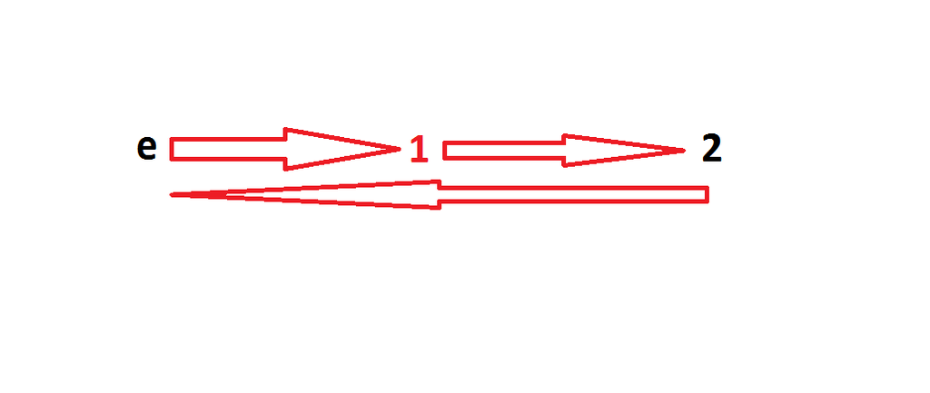

Sample gen graph for C(3)

We usually put the elements of a cyclic group in a line.

## Product of a group and a cyclic group kernel

We have 2 choices. Here is the example with S3

- This is the product correct way:

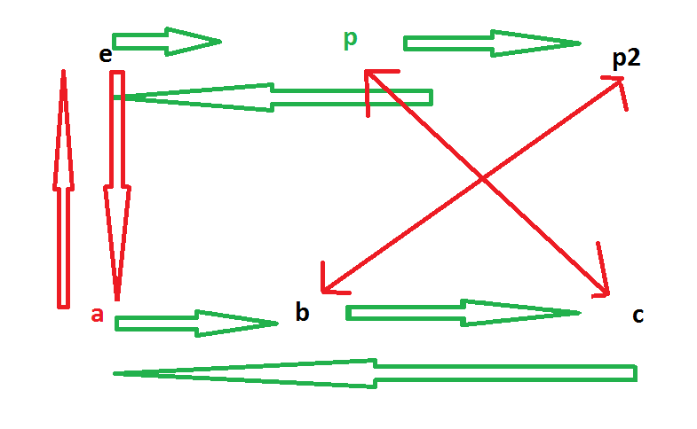

- This is the straight edge way:

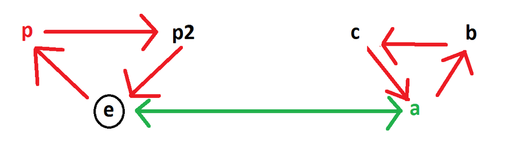

# All Subgroups of a Group

Let G be a group, let $0 \rightarrow N \rightarrow G \rightarrow Q \rightarrow 0$ be a decomposition.

## Finding All the Normal Subgroups

We assume that we know all the normal subgroups of N and Q.